# Seek Inversions from Mispaired and Split Reads

Eric C. Anderson

Last Updated: 2020-05-14

# Packages and paths

```r
library(tidyverse)


dir.create("outputs/201", recursive = TRUE, showWarnings = FALSE)
dir.create("intermediates/201", recursive = TRUE, showWarnings = FALSE)
```

# Read in and explore the results computed on the cluster

```r
depths <- read_tsv("stored_results/201/read-depths-by-base-pair-and-pair-type.tsv.gz")

d2 <- depths %>%
  mutate(
    fall_mispair_ppn = fall.aberrant.bam / fall.2Mb.bam,
    spring_mispair_ppn = spring.aberrant.bam / spring.2Mb.bam
  )
```

Now, plot those alongside one another.

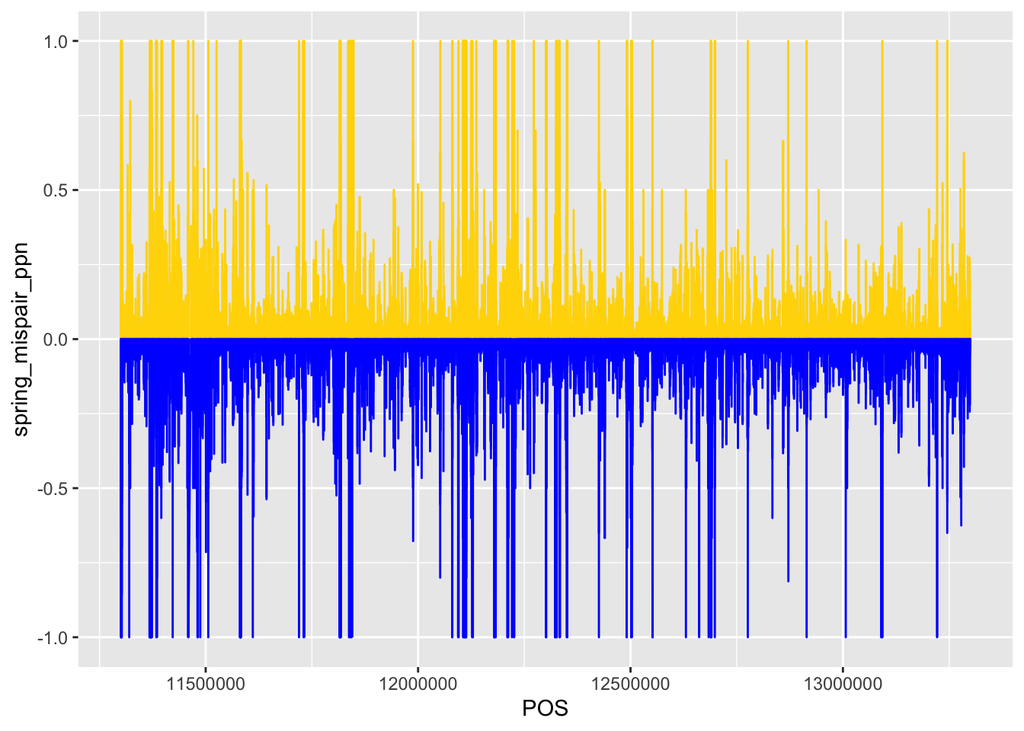

```r
quick_lines <- function(d2) {
  ggplot() +
    geom_line(data = d2 %>% filter(!is.na(spring_mispair_ppn)), mapping = aes(x = POS, y = spring_mispair_ppn), colour = "gold") +
    geom_line(data = d2 %>% filter(!is.na(fall_mispair_ppn)), mapping = aes(x = POS, y = -fall_mispair_ppn), colour = "blue")
}

mp <- quick_lines(d2)

ggsave(mp, filename = "outputs/201/mispair_spring_v_fall.png", width = 15, height = 7)

mp
```

So, those are quite symmetrical. What we need to do here is filter the results down to cases where we have at least a read depth of X and a one of fall or spring prortion being greater than P while the absolute difference between then two is at least D:

```r
filt_rd <- function(data, X, P, D) {
  data %>%
    filter((fall.2Mb.bam > X | spring.2Mb.bam > X) &
      (spring_mispair_ppn > P | fall_mispair_ppn > P) &
      (abs(spring_mispair_ppn - fall_mispair_ppn) > D))
}
```

First just try filtering:

```r
filt1 <- filt_rd(d2, 35, 0.8, 0.5)

# that suggests a single interesting region:
filt1 %>% select(POS, starts_with("fall"), starts_with("spring"))
```

| POS | fall.2Mb.bam | fall.aberrant.bam | fall.mates_unmapped.bam | fall.split_reads.bam | fall_mispair_ppn | spring.2Mb.bam | spring.aberrant.bam | spring.mates_unmapped.bam | spring.split_reads.bam | spring_mispair_ppn |
| --- | --- | --- | --- | --- | --- | --- | --- | --- | --- | --- |
| 12272302 | 64 | 0 | 0 | 0 | 0 | 2 | 2 | 2 | 0 | 1 |
| 12272303 | 63 | 0 | 0 | 0 | 0 | 2 | 2 | 2 | 0 | 1 |
| 12272304 | 61 | 0 | 0 | 0 | 0 | 2 | 2 | 2 | 0 | 1 |
| 12272305 | 61 | 0 | 0 | 0 | 0 | 2 | 2 | 2 | 0 | 1 |
| 12272306 | 59 | 0 | 0 | 0 | 0 | 2 | 2 | 2 | 0 | 1 |
| 12272307 | 61 | 0 | 0 | 0 | 0 | 2 | 2 | 2 | 0 | 1 |
| 12272308 | 64 | 0 | 0 | 0 | 0 | 2 | 2 | 2 | 0 | 1 |
| 12272309 | 64 | 0 | 0 | 0 | 0 | 2 | 2 | 2 | 0 | 1 |
| 12272310 | 64 | 0 | 0 | 0 | 0 | 1 | 1 | 1 | 0 | 1 |
| 12272311 | 63 | 0 | 0 | 0 | 0 | 1 | 1 | 1 | 0 | 1 |

[output cut: 8 more lines]

That is one spot where the falls have plenty of reads aligning, but the springs have very few (only 1 or two). However, all of the reads aligning in springs are mispaired.

It turns out that is the exception that proves the rule. That segment is a 22-bp deletion carried on the $E$-lineage haplotype—it isn’t an indication of an inversion of any sort.

# Now, look for split reads

```r
dsplit <- depths %>%
  mutate(
    fall_split_ppn = fall.split_reads.bam / fall.2Mb.bam,
    spring_split_ppn = spring.split_reads.bam / spring.2Mb.bam
  )
```

And plot those all along the 2 Mb:

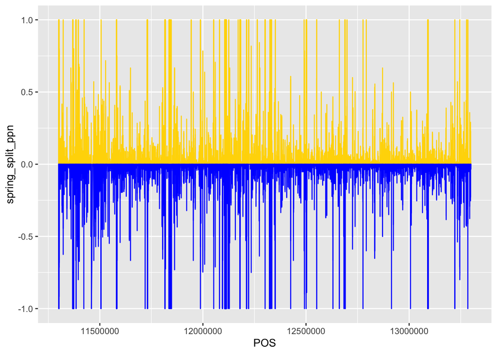

```r
split_ppn <- ggplot() +
  geom_line(data = dsplit %>% filter(!is.na(spring_split_ppn)), mapping = aes(x = POS, y = spring_split_ppn), colour = "gold") +
  geom_line(data = dsplit %>% filter(!is.na(fall_split_ppn)), mapping = aes(x = POS, y = -fall_split_ppn), colour = "blue")

ggsave(split_ppn, filename = "outputs/201/split_read_ppn_spring_v_fall.png", width = 15, height = 7)

split_ppn
```

That looks a lot like the mispaired reads plot. So, let’s filter down in the same way and see if we find any that are really different between falls and springs.

```r
filt_for_splits <- function(data, X, P, D) {
  data %>%
    filter((fall.2Mb.bam > X | spring.2Mb.bam > X) &
      (spring_split_ppn > P | fall_split_ppn > P) &
      (abs(spring_split_ppn - fall_split_ppn) > D))
}


filt2 <- filt_for_splits(dsplit, 35, 0.7, 0.3)

filt2
```

| #CHROM | POS | fall.2Mb.bam | fall.aberrant.bam | fall.mates_unmapped.bam | fall.split_reads.bam | late_fall.2Mb.bam | late_fall.aberrant.bam | late_fall.mates_unmapped.bam | late_fall.split_reads.bam | spring.2Mb.bam | spring.aberrant.bam | spring.mates_unmapped.bam | spring.split_reads.bam | winter.2Mb.bam | winter.aberrant.bam | winter.mates_unmapped.bam | winter.split_reads.bam | fall_split_ppn | spring_split_ppn |
| --- | --- | --- | --- | --- | --- | --- | --- | --- | --- | --- | --- | --- | --- | --- | --- | --- | --- | --- | --- |
| NC_037124.1 | 11528114 | 72 | 12 | 0 | 28 | 21 | 7 | 1 | 14 | 92 | 26 | 0 | 65 | 34 | 8 | 1 | 19 | 0.38888889 | 0.7065217 |
| NC_037124.1 | 11528115 | 73 | 13 | 0 | 29 | 22 | 7 | 1 | 15 | 92 | 26 | 0 | 66 | 34 | 8 | 1 | 19 | 0.39726027 | 0.7173913 |
| NC_037124.1 | 11528116 | 73 | 13 | 0 | 29 | 22 | 7 | 1 | 15 | 92 | 26 | 0 | 66 | 36 | 9 | 1 | 19 | 0.39726027 | 0.7173913 |
| NC_037124.1 | 12234265 | 52 | 3 | 1 | 9 | 23 | 2 | 0 | 4 | 12 | 7 | 0 | 9 | 2 | 0 | 0 | 1 | 0.17307692 | 0.7500000 |
| NC_037124.1 | 12332752 | 40 | 5 | 0 | 3 | 5 | 2 | 1 | 1 | 6 | 3 | 0 | 6 | 4 | 1 | 0 | 0 | 0.07500000 | 1.0000000 |
| NC_037124.1 | 12332753 | 41 | 5 | 0 | 4 | 5 | 2 | 1 | 1 | 6 | 3 | 0 | 6 | 4 | 1 | 0 | 0 | 0.09756098 | 1.0000000 |
| NC_037124.1 | 12332754 | 41 | 5 | 0 | 4 | 5 | 2 | 1 | 1 | 6 | 3 | 0 | 6 | 4 | 1 | 0 | 0 | 0.09756098 | 1.0000000 |
| NC_037124.1 | 12332755 | 41 | 5 | 0 | 4 | 5 | 2 | 1 | 1 | 6 | 3 | 0 | 6 | 4 | 1 | 0 | 0 | 0.09756098 | 1.0000000 |
| NC_037124.1 | 12332756 | 41 | 5 | 0 | 4 | 5 | 2 | 1 | 1 | 6 | 3 | 0 | 6 | 4 | 1 | 0 | 0 | 0.09756098 | 1.0000000 |
| NC_037124.1 | 12332757 | 41 | 5 | 0 | 4 | 5 | 2 | 1 | 1 | 6 | 3 | 0 | 6 | 4 | 1 | 0 | 0 | 0.09756098 | 1.0000000 |

[output cut: 30 more lines]

This indicates two regions worth following up on. One is at POS = 12,234,265. The other is a range from 12,332,752-12,332,787.

POS = 12,234,265 is in the middle of a deletion (from 21 to 27 bp in various individuals), and there are a handful of reads from springers that span that deletion and also have supplementary alignments (most on different chromosomes, and no clusters to other nearby locations on Chr. 28). Conclusion = this is not an indication of an inversion.

As for 12,332,752-12,332,787, looking at this in IGV, there are very few reads mapping there from spring run, and those that do have very low MAPQs. The supplemental alignments are not to a consistent location on Chr 28, so there seems no way these could indicate an inversion breakpoint in this region.

# Running Time

Running the code and rendering this notebook required approximately this much time on a Mac laptop of middling speed:

```r
Sys.time() - start_time
```

```
## Time difference of 3.538503 mins
```

Citations